# Cotas para escola pública na USP e inclusão racial - Subsídios para a Congregação do IBUSP

Paulo Inácio Prado (Depto de Ecologia, IBUSP)

22 de junho de 2016

# Contextualização

Em 2013 a USP estabeleceu em seu Plano Institucional [^1] as seguintes metas para 2018:

> “I- 50% (cinquenta por cento) dos alunos matriculados em cada curso e em cada turno tendo cursado integralmente o ensino médio em escolas públicas;

> II – dentro desses 50% (cinquenta por cento) de matriculados oriundos de escolas públicas, o percentual de pretos, pardos e indígenas deverá atingir aquele verificado pelo último censo demográfico do IBGE."

> O Programa de inclusão social da USP (INCLUSP) iniciou-se em 2007, concedendo bônus de 3% nas notas das duas fase dos vestibular para candidatos que cursaram todo ensino médio em escolas públicas.Nos anos seguintes critérios e valores de bônus foram gradativamente aumentados."

A partir do vestibular de 2014 foi incluído um bônus adicional de 5% aos candidatos de escolas públicas que se auto-identificarem como “pretos, pardos ou indígenas” (PPI).

A FUVEST disponibiliza em seu site os resultados de sua pesquisa de perfil sócio-econômico dos candidatos, convocados e matriculados. A partir do ano de 2000 a pesquisa pergunta a raça/cor dos candidatos, com as opções “branca”, “preta”, “parda”, “amarela”, “indígena”. Os dados sobre aprovados e matriculados do vestibular de 2016 ainda não estão disponíveis.

# Progresso das metas desde sua proposição

De acordo com o censo demográfico de 2010, as pessoas que se declaram como PPI representam 36,7% da população do estado de São Paulo e 55,2% da população brasileira.

De acordo com o site da FUVEST e anuário da USP:

- Entre os que se matricularam de 2010 a 2015, 27,5% dos que optaram pelo INCLUSP[^2] se declararam PPI.
- Entre os matriculados que optaram pelo INCLUSP , 32,1% se declararam PPI em 2015. Este percentual foi de 30% em 2014 e de 24,7% em 2013.
- Entre os que se matricularam de 2010 a 2015, 25% cursaram integralmente o ensino médio em escolas públicas.
- 34,8% dos matriculados do vestibular de 2015 cursaram integralmente o ensino médio em escolas públicas. Este percentual foi de 32,2% em 2014 e de 27,8% em 2013.

## Probabilidade de ingresso na USP

Os gráficos a seguir comparam a proporção de matriculados após a última chamada em relação ao número de inscritos em relação à origem escolar e raça. Os dados foram obtidos do site da FUVEST e do anuário da USP. Os dados estão agregados em três períodos:

- Antes da criação do INCLUSP: 2000 - 2006
- Antes inclusão de bônus racial no INCLUSP: 2007-2013
- Após inclusão de bônus racial no INCLUSP: 2014-2015

### Probabilidade de ingresso de oriundos da escola particular e pública

O gráfico mostra a proporção matriculados/inscritos para candidatos que cursaram o ensino médio integralmente em escola pública ou não, em cada período. As barras são intervalos de confiança. Os traços pretos indicam a relação candidato/vaga de cada vestibular. Se houvesse igualdade de condições todas as proporções deveriam convergir para estes valores.

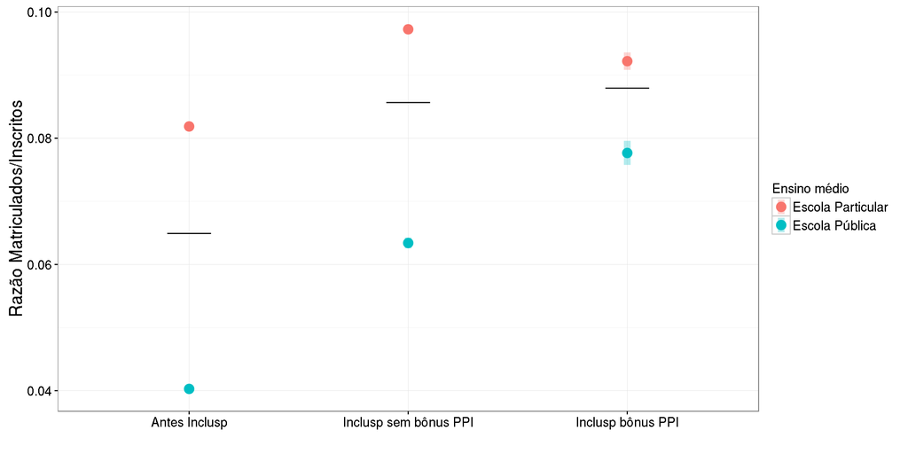

### Probabilidade de ingresso de candidatos PPI

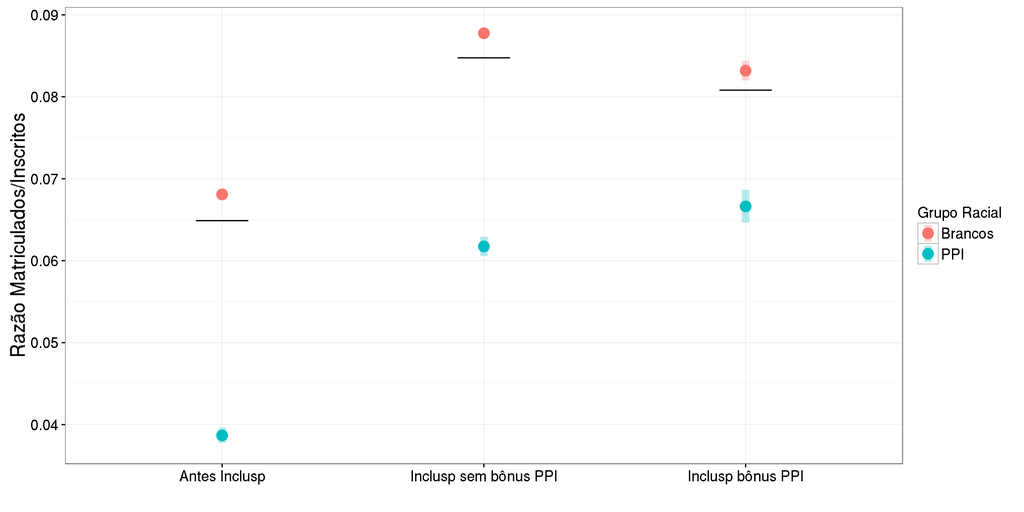

## INCLUSP e inclusão racial

O último gráfico mostra a proporção matriculados/ingressantes de candidatos PPI e brancos, dentro e fora do INCLUSP. A comparação foi feita entre os períodos em que programa não tinha bônus racial (2007-2013) e após a inclusão deste bônus (2014-2015).

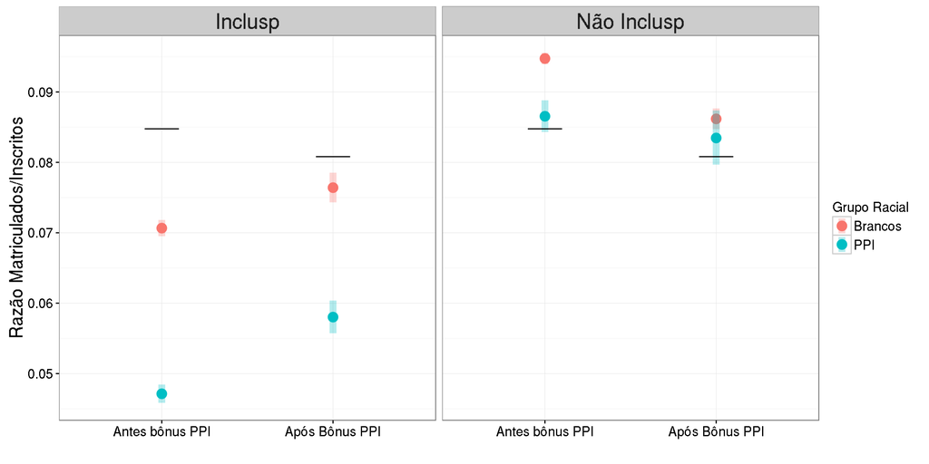

Mesmo com o bônus, os candidatos INCLUSP tiveram menor probabilidade de ingresso. Mais importante, a desigualdade racial é maior no grupo de candidatos que aderiram ao INCLUSP. O bônus racial de 5% reduziu um pouco essa desigualdade, mas os candidatos PPI oriundos de escola pública são ainda o grupo com menor probabilidade de ingresso.

Portanto, inclusão sócio-econômica não é capaz de reduzir desigualdades raciais, porque essas desigualdades estão presentes em todos os estratos sócio-econômicos. No caso em análise, o quadro é ainda pior, pois as desigualdades raciais se acentuam justo no estrato mais carente.

## Fonte de dados

Os dados de raça declarada foram obtidos do site da FUVEST (http://www.fuvest.br/, seção “Estatísticas” > “Questionário de Avaliação Sócio-Econômica”), usando os agrupamentos “Total carreiras USP” e “Candidatos que optaram pelo Inclusp”. Os dados de onde os candidatos curasaram o ensino médio foram retirados do anuário da USP (https://uspdigital.usp.br/anuario/).

[^1]: RESOLUÇÃO Nº 6583, DE 4 DE JULHO DE 2013, http://www.leginf.usp.br/?resolucao=resolucao-no-6583-de-4-de-julho-de-2013
[^2]: Os dados divulgados não permitem cruzar diretamente a pergunta sobre raça e onde cursou o ensino médio. No entanto, estão disponíveis os dados sobre raça dos optantes pelo Inclusp. Para optar pelo Inclusp é preciso ter cursado o ensino médio integralmente eme scola pública. É possível que alguns candidatos com este perfil não tenham se inscrito no Inclusp, mas dadas as vantagens de se inscerevr isso não deve alterar muito os resultados.